# Trends in Chlorophyll

# Data

## Collection Methods

Water samples were collected monthly at each of the four water quality monitoring stations at the GTMNERR for nitrite + nitrate, ammonium, total nitrogen, orthophosphate, total phosphorus, chlorophyll a, and total suspended solids using two types of sampling methods (grab and diel), on the same day during an ebb tide. Grab samples were collected from all stations in duplicate using a pole sampler and bucket. Diel samples were only collected at the Pellicer Creek station at 2.5-hour intervals for a 25-hour (lunar day) period using a Teledyne ISCO automatic sampler equipped with an internal ice bath to keep samples cold. Both grab and diel samples were collected from the approximate depth of the sonde sensors, 1 m above the bottom. Samples were filtered in the field whenever feasible; otherwise, they were placed on ice in the dark and filtered immediately upon returning to the laboratory.

Water samples collected between January 1, 2003 and June 30, 2010 were collected and analyzed by University of Florida’s (UF) Department of Fisheries and Aquatic Sciences. Samples collected between July 1, 2010 and November 30, 2012 were collected by GTMNERR and analyzed by the UF lab. Samples collected on or after December 1, 2012 were collected by GTMNERR and analyzed by the Florida Department of Environmental Protection’s (FDEP) Central Laboratory. Both laboratories were certified through the National Environmental Laboratory Accreditation Program and used the American Public Health Association and Environmental Protection Agency methods for analyses. Method details can be found in annual metadata files at www.nerrsdata.org.

## The data set

Loading the nutrient data file and cleaning it up for analysis. This file is an appended internal file to the GTMNERR that contains data from 2002-2023 with QC flags and codes and all the parameters included. This data is not included in the GitHub repository, but can be requested from the GTMNERR.

```
Rows: 4,713
Columns: 81
$ station_code       <chr> "gtmpcnut", "gtmpcnut", "gtmssnut", "gtmssnut", "gt…
$ date_time_stamp    <dttm> 2002-05-08 08:15:00, 2002-05-08 08:15:00, 2002-05-…
$ monitoring_program <dbl> 1, 1, 1, 1, 1, 1, 1, 1, 1, 1, 1, 1, 1, 1, 1, 1, 2, …
$ rep                <dbl> 1, 2, 1, 2, 1, 2, 1, 2, 1, 2, 1, 2, 1, 2, 1, 2, 1, …
$ f_record           <chr> NA, NA, NA, NA, NA, NA, NA, NA, NA, NA, NA, NA, NA,…
$ po4f               <dbl> 0.056, 0.057, 0.035, 0.029, 0.007, 0.027, 0.009, 0.…
$ f_po4f             <chr> "<4>", "<4>", "<4>", "<4>", "<4>", "<4>", "<4>", "<…
$ tdp                <dbl> NA, NA, NA, NA, NA, NA, NA, NA, NA, NA, NA, NA, NA,…
$ f_tdp              <chr> "<4>", "<4>", "<4>", "<4>", "<4>", "<4>", "<4>", "<…
$ tp                 <dbl> 0.073, 0.074, 0.045, 0.012, 0.034, 0.047, 0.026, 0.…
$ f_tp               <chr> "<4>", "<4>", "<4>", "<4>", "<4>", "<4>", "<4>", "<…
$ dop                <dbl> NA, NA, NA, NA, NA, NA, NA, NA, NA, NA, NA, NA, NA,…
$ f_dop              <chr> "<-1>", "<-1>", "<-1>", "<-1>", "<-1>", "<-1>", "<-…
```

[output cut: 68 more lines]

# Data preparation

## Selecting and filtering QAQC flags and codes

We are interested in examining trends in chlorophyll *a* (chl-a) for complete years across a 20 year period. Therefore, we are only selecting the chl-a data from 2003-2022 at all stations. This dataset includes both grab and diel collection results, so the diel data will be filtered out as well.

```r
chla <- NUT %>%
          filter(!is.na(rep)) %>% # remove "S" reps in dataset
          select(station_code, 2:5, chla_n, f_chla_n) %>% # keep only chla data
          rename(datetimestamp = date_time_stamp) %>% # clean name
          mutate(date = lubridate::date(datetimestamp)) %>% # create date variable from POSIXct
          filter(monitoring_program == 1) %>% # keep only grab samples (remove DIEL)
          select(-monitoring_program, -rep) # remove columns once done

glimpse(chla)
```

```
Rows: 2,012
Columns: 6
$ station_code  <chr> "gtmpcnut", "gtmpcnut", "gtmssnut", "gtmssnut", "gtmpinu…
$ datetimestamp <dttm> 2002-05-08 08:15:00, 2002-05-08 08:15:00, 2002-05-08 09…
$ f_record      <chr> NA, NA, NA, NA, NA, NA, NA, NA, NA, NA, NA, NA, NA, NA, …
$ chla_n        <dbl> 12.7, 12.3, 5.8, 5.6, 10.3, 16.1, 4.9, 5.6, 6.0, 3.1, 5.…
$ f_chla_n      <chr> "<4>", "<4>", "<4>", "<4>", "<4>", "<4>", "<4>", "<4>", …
$ date          <date> 2002-05-08, 2002-05-08, 2002-05-08, 2002-05-08, 2002-05…
```

The F_Record column contains [QAQC codes](https://cdmo.baruch.sc.edu/data/qaqc.cfm) that apply to the entire record. We want to look at what all are included in this dataset.

```r
# examine f_record values for further filtering
unique(chla$f_record)
```

```
[1] NA      "{TSH}" "{CSM}" "{WS2}" "{CLE}" "{CIF}" "{NE}"
```

All of those codes are okay, none of the records require further filtering. Next will be to look at the flags and codes for the chl-a results:

```r
# examine f_chla values for further filtering
unique(chla$f_chla_n)
```

```
 [1] "<4>"             "<-4> [SBL]"      "<0>"             "<-3> [GQD]"
 [5] "<0> (CSM)"       "<1> (CSM)"       "<1> [SRD]"       "<1> (CUS)"
 [9] "<1> [SRD] (CSM)" "<-3> (CSM)"
```

This data contains several records that will not be good to keep for the analysis. Examining the suspect data (“<1>”) it seems a lot of that data contains CSM codes and metadata documentation that says these reference “Laboratory indicated that the values reported are the mean of two or more determinations” and values were estimated. For now, all rejected and suspect data will be removed for analysis. I also removed the data flagged with “<-4>” which means “below sensor limit”. This means this data was below the minimum detection limit from lab.

### Nominal base MDL

There are also quite a few very low values that occur early on in the timeseries:

```r
head(chla %>% arrange(chla_n))
```

```
# A tibble: 6 × 6
  station_code datetimestamp       f_record chla_n f_chla_n   date
  <chr>        <dttm>              <chr>     <dbl> <chr>      <date>
1 gtmpcnut     2003-01-22 07:55:00 <NA>       0.01 <-4> [SBL] 2003-01-22
2 gtmpcnut     2003-01-22 07:55:00 <NA>       0.01 <-4> [SBL] 2003-01-22
3 gtmpcnut     2004-09-13 08:05:00 <NA>       0.01 <4>        2004-09-13
4 gtmfmnut     2003-01-22 16:40:00 <NA>       0.1  <4>        2003-01-22
5 gtmpcnut     2004-09-13 08:06:00 <NA>       0.1  <4>        2004-09-13
6 gtmpcnut     2006-02-14 16:02:00 <NA>       0.2  <4>        2006-02-14
```

These values fall below the nominal base minimum detection limit (MDL) for chl-a used in the last 10 years of the record which is 0.55($\mu$g/L). Therefore, any values less than this MDL will be set to that MDL. This will apply to these records:

```r
chla %>% filter(chla_n < 0.55)
```

```
# A tibble: 12 × 6
   station_code datetimestamp       f_record chla_n f_chla_n   date
   <chr>        <dttm>              <chr>     <dbl> <chr>      <date>
 1 gtmpcnut     2003-01-22 07:55:00 <NA>       0.01 <-4> [SBL] 2003-01-22
 2 gtmpcnut     2003-01-22 07:55:00 <NA>       0.01 <-4> [SBL] 2003-01-22
 3 gtmfmnut     2003-01-22 16:40:00 <NA>       0.4  <4>        2003-01-22
 4 gtmfmnut     2003-01-22 16:40:00 <NA>       0.1  <4>        2003-01-22
 5 gtmpcnut     2003-03-22 15:28:00 <NA>       0.4  <4>        2003-03-22
 6 gtmpcnut     2004-09-13 08:05:00 <NA>       0.01 <4>        2004-09-13
 7 gtmpcnut     2004-09-13 08:06:00 <NA>       0.1  <4>        2004-09-13
 8 gtmfmnut     2005-02-07 13:46:00 <NA>       0.4  <4>        2005-02-07
 9 gtmfmnut     2005-03-07 10:45:00 <NA>       0.4  <4>        2005-03-07
10 gtmpcnut     2005-07-07 13:30:00 <NA>       0.4  <4>        2005-07-07
11 gtmpcnut     2006-02-14 16:01:00 <NA>       0.4  <4>        2006-02-14
12 gtmpcnut     2006-02-14 16:02:00 <NA>       0.2  <4>        2006-02-14
```

This will replace all these values with the nominal base MDL of 0.55($\mu$g/L).

```r
chla$chla_n[chla$chla_n < 0.55] <- 0.55 # replace all values below nominal base mdl of 0.55 with the base mdl 0.55
```

## Formatting for analysis

So, filtering the data to remove unusable QC data, then averaging the duplicates for a monthly average chl-a at each site (`value`), and then adding information to match the format used for the `wqtrends` [workflow](https://tbep-tech.github.io/wqtrends/articles/introduction.html) (Beck et al. 2022). This means adding a few columns such as `doy` (day of year), `cont_year` (date in decimal time), `yr` (year), `mo` (month as character label), and `param` which is probably not necessary, but since it was included in the vignette, I added a column to make it clear this is chl-a data. This is also where I filtered to remove 2002 and 2023 data since they are not of interest for this trend analysis.

```r
# prep data for GAM

chla_dat <- chla %>%
              filter(!grepl(c("<-3>"), f_chla_n) &
                       !grepl(c("<1>"), f_chla_n) &
                        !grepl(c("<-4>"), f_chla_n)) %>% # remove rejected and suspect data
              select(-f_record, -f_chla_n) %>% # remove qc columns after filtering
              group_by(station_code, date) %>% # group by station and date to average duplicates
              summarise(value = mean(chla_n, na.rm = T)) %>% # avg duplicates
              ungroup() %>%
              mutate(doy = lubridate::yday(date), # day of the year
                     cont_year = lubridate::decimal_date(date), # date in decimal time
                     yr = lubridate::year(date), # year
                     mo = lubridate::month(date, label = TRUE), # month
                     param = "chla") %>% # add param name
              rename(station = station_code) %>% # clean variable name
              filter(yr > 2002 & yr < 2023) # only keep data from 2003-2022

head(chla_dat)
```

```
# A tibble: 6 × 8
  station  date       value   doy cont_year    yr mo    param
  <chr>    <date>     <dbl> <dbl>     <dbl> <dbl> <ord> <chr>
1 gtmfmnut 2003-01-22  0.55    22     2003.  2003 Jan   chla
2 gtmfmnut 2003-02-26  1.2     57     2003.  2003 Feb   chla
3 gtmfmnut 2003-03-26  1.5     85     2003.  2003 Mar   chla
4 gtmfmnut 2003-04-29  5.05   119     2003.  2003 Apr   chla
5 gtmfmnut 2003-05-27  3.15   147     2003.  2003 May   chla
6 gtmfmnut 2003-06-25  3.45   176     2003.  2003 Jun   chla
```

## Values

I want to examine the data available for each station and see where data may be missing.

```r
chla_dat %>%
  filter(station == "gtmpinut") %>%
  select(value, yr, mo) %>%
  pivot_wider(names_from = mo, values_from = value, id_cols = yr)
```

```
# A tibble: 20 × 13
      yr   Jan   Feb   Mar   Apr   May   Jun   Jul   Aug   Sep   Oct   Nov   Dec
   <dbl> <dbl> <dbl> <dbl> <dbl> <dbl> <dbl> <dbl> <dbl> <dbl> <dbl> <dbl> <dbl>
 1  2003  3.85  5.9   3.25  9.25  9.3  10.6   7.4   5.55  3.5   6     5.6   4.3
 2  2004  3.95  3.45  4     6.75  3.35  6.95  9.85  3.25  1.35  2.25  1.3   2.05
 3  2005 NA     2.05  1.65  5.75  4.4   6.5   3.45  7.9   4.6   2.1   1.1   2.2
 4  2006  1.65  4.65  2.55  5     1.8   3     4.35  7.05  6.15  4.7   5.6   5.4
 5  2007  4.6   4.35  4.9   6.25  4.6   5.35  9.25 12.8   8.3   2.2   3.5   4.35
 6  2008  3.5   4.9   4.35  5.5   6.35 12.0  14.2   6.8   5     4.8   5.5   4.9
 7  2009  3.5   4.35  4.5   6.15  8.5  NA    15.4   8.6   2.55  2.75  4.55  2.4
 8  2010  1.7  NA     6.7   9.5   8.95 11.8   9.85  9.15  9.7   4.6   5.4   6.7
 9  2011  5.05  5.5   6.5   5.6   9.05  8.7   5.1   8.6   6     9.2   7.95  4.45
10  2012  4.9   3.9   8.25  8.6   5.05  7.3   6.8   3.05  2.9   3.7   3.8   3.3
11  2013  3.65  2.75  3.15  3.4   3.3   3.5   7.6   3.95  2.8   2.2   2.9   3.5
12  2014  2.05  3     2.35  2.95  5.1   5.35  9.35  8.1   4.45  3.65  4.5   4
13  2015  2.9   2.4   9.15  7.45  4.45  8.4  13    NA     2.05  1.75  2.7   2.95
14  2016  3.65  4.4   3.8   7     3.6  11.5  13.5   8.6   6.5   2.4   4.05  3.05
15  2017  4.55  5.05  5.15  4.75  6.85  3.35 13.1   5.4   3.05  1.95  2.2   1.7
16  2018  3.5   3.1   2.7   5.3   6.8   5     4.35 11     3.75  5     4.05  2.85
17  2019  5.95  2.1   3.2   4.35  4.75  2.5  10.5  10.4   3.3   5.1   3.6   2.9
18  2020  3.75  5.8   5.15 12    11.3   7.8   8.7  NA     2.6   2.6   5.25  3.95
19  2021  4.8   2.35  2.8   6.5  11    10.5   7.3   4.6   6.15  5.25  4.4   5.5
20  2022  6.75  3.3   4.5  18.5  13    12.5  16    13.5   5.25  5.3   3.95  3.2
```

gtmpinut data missing for 2005-01, 06-2009, 02-2010, 08-2015, 08-2020.

```r
chla_dat %>%
  filter(station == "gtmssnut") %>%
  select(value, yr, mo) %>%
  pivot_wider(names_from = mo, values_from = value, id_cols = yr)
```

```
# A tibble: 20 × 13
      yr   Jan   Feb   Mar   Apr   May   Jun   Jul   Aug   Sep   Oct   Nov   Dec
   <dbl> <dbl> <dbl> <dbl> <dbl> <dbl> <dbl> <dbl> <dbl> <dbl> <dbl> <dbl> <dbl>
 1  2003  1.75  2.55  2.4   6.15  5     4     4.7   4.3   5.65  4.6   5.45  2.4
 2  2004  3.1   4.7   1.6   3.75  2.65  5.95  3.3   3.6   3.7   2.15  2.95  2.45
 3  2005 NA     1.8   1.55  3.2   1.7   4.15  2.65  3.25  3.8   1.9   1.45  1.65
 4  2006  0.9   1.2   1.35  4.35  2.6   1.7   2.45  1.75  8.7   3.6   5.8   4
 5  2007  3.7   2.3   4.35  3.9   3     2.2   4.9   4.45  4.6  14.0   4     3
 6  2008  2.3   3.1   5.25  7.25  5.8   6.6   7.1   4     8.25  8.25  6.8   6.1
 7  2009  1.2   2.1   4.7   3.9   6.05 NA     5.25  9.05  3.35  4     4.1   3.15
 8  2010  5.95 NA     4.35  4.9   8.85  9.5   8.7   6.95  6.5   6     5.15  4.9
 9  2011  3.8   2.8   4.25  4.95  5.5   5.5   4.8   4.8   6.05  7.05  5.4   4
10  2012  2.55  2.9   6.35  4.35  4.9   5.05  4.25  3.6   4.95  4.35  3.8   3.05
11  2013  3.4   2.35  2     3     4.05  4.85  9.6   3.2   3.75  4.6   3.25  2.6
12  2014  2.8   2.4   1.8   1.95  5.1   6.65  6.5   9.1   4.4   5.85  4.4   1.75
13  2015  3.4   3.15  4.3   3.35  4.15  9.05  8.5   8.55  3.85  2.75  2.8   6.6
14  2016  2.95  2.05  3.6   3.15  5.75  4.7  10.5   6.3   5.5   4.35  3.1   2.6
15  2017  2.5   3.2   3     3.05  3.65  2.45  2.6   3.1   4.05  2     4.55  1.9
16  2018  3.7   2.75  2.6   2.55  8.25  4.6   3.4   5.6   4.4   4.95  6.35  7.15
17  2019  6.4   3.7   3.85  4.5   6.9   6.3   7.7   5.4  NA     8.9   4.6   5.9
18  2020  3.3   4.2   2.5   4.05  4.95  6.95  7.9  NA     5.1   4.3   3.7   3
19  2021  3.35  2     3     3.65  8.7   8.35 11.5   8.3   6.9   5.1   6.6   3.25
20  2022  6.85  5.6   4.45  5.3   5.15  7.65 NA     6.5   4.7   5.75  4.8   2.45
```

gtmssnut data missing for 2005-01, 06-2009, 02-2010, 09-2019, 08-2020, 07-2022

```r
chla_dat %>%
  filter(station == "gtmfmnut") %>%
  select(value, yr, mo) %>%
  pivot_wider(names_from = mo, values_from = value, id_cols = yr)
```

```
# A tibble: 20 × 13
      yr   Jan    Feb   Mar   Apr   May   Jun   Jul   Aug   Sep   Oct   Nov
   <dbl> <dbl>  <dbl> <dbl> <dbl> <dbl> <dbl> <dbl> <dbl> <dbl> <dbl> <dbl>
 1  2003  0.55  1.2   1.5    5.05  3.15  3.45  2.5   2.4   3.85  2.85  2.85
 2  2004  1.05  1.1   1.5    2.95  3.95  4.4   3.45  2.8   3.1   2.9   2.5
 3  2005 NA     0.825 0.575  3.5   2.45  3.85  3.9   2.7   2.7   1.9   2.1
 4  2006  0.8   0.9   1.2    2.9   2.25  1.45  2.1   4.9   7.3   4.7   3.9
 5  2007  1.55  1.3   2      6.7   3.35  4.45  5.25 10.7   4.9  23.5   2.8
 6  2008  1.6   2.3   3      3.8   5.25 11.0   8.5   4.2   5.9   6.25  3.4
 7  2009  2.4   1.7   5.6    4.1   1.9  NA     4.9   5.25  3     4.95  4.7
 8  2010  4.8  NA     3.4    3.9   7.4   8.8   6.15  6.55  4.35  4.25  3
 9  2011  1.8   2.2   3.25   3.9   5.8   3.8   4.35  4.2   5     6     3.6
10  2012  2.8   1.7   3.5    3.8   3.4   4.45  3.7   2.7   4.2   3.25  1.8
11  2013  1.7   1.2   1.55   2.95  4     4.4   5.8   3.1   3.15  4.8   2.4
12  2014  1.75  1.65  2.35   2.85  5.2   4.65  7.15  6.15  4.45  4.25  3.5
13  2015  1.75  1.7   2.7    3.5   4.6  11.5   9.6   8.15  3.65  2.3  NA
14  2016  1.09  0.93  1.1    4.05  5.15  4.25  6.3   5.2   3.35  2.05  2.4
15  2017  1.5   1.85  2.3    3     4.15  4.55  2.25  4.35  2.45  1.55  2.75
16  2018  1.45  1.75  2.15   2.7  15.5   6.35  4.85  5.8   5.1   4     3.95
17  2019  6.6   3.55  2      2.9   4.55  3.8   5.05  4.75  5     6.45  3.55
18  2020  3.9   5.4   2.55   3.85  5.7   5.3   7.55  4.4   3.1   2.65  4.15
19  2021  1.1   1.55  1.65   2.2   6.5  11     8.7   7.2   4     4.9   4
20  2022  5.2   4.3   4.25   4.5   5.55  5.5   5.6   3.3   3.8   5.2   4.3
# ℹ 1 more variable: Dec <dbl>
```

gtmfmnut needs NAs placed for 2005-01, 06-2009, 02-2010, 11-2015

```r
chla_dat %>%
  filter(station == "gtmpcnut") %>%
  select(value, yr, mo) %>%
  pivot_wider(names_from = mo, values_from = value, id_cols = yr)
```

```
# A tibble: 20 × 13
      yr   Feb   Mar   Apr   May   Jun    Jul    Aug   Sep   Oct   Nov   Dec
   <dbl> <dbl> <dbl> <dbl> <dbl> <dbl>  <dbl>  <dbl> <dbl> <dbl> <dbl> <dbl>
 1  2003  3.65  1.08  5.3   7.5   8.9   9.05   2.7    4.8   3.4   3.6   2.95
 2  2004  1.75  1.6   7.3   6.8   8.5  24.6    1.35   0.55  4.55  2.7   7.05
 3  2005  3.45  7.35  0.9   3.5   2.7   0.575 10.4    4.1   2.8   1.45  1.3
 4  2006  0.55  5.15  3.6   4.85  8.35  8.75  13.0   13.0   6.8   7.7   4.9
 5  2007  8.8   9.5  18.4   9.4  14.3  17.9   25.4   13.6   4.6   4     6.95
 6  2008 10.6   7.35  9.8  12.0  21.2  24.6   16.6   11.0   8.25  8.15  4.9
 7  2009  8.8  13.2  15.6  17.8   1.3  11.7    1.9   NA     8.15  9.05  6
 8  2010 NA     1.55  4.25 16.2  23.2  18.5   23.8   24.1  10.5  10.2   9.8
 9  2011  7.95 11.2  11.4  17.6  19.3  31.0   38.2   21.1  11.5   9.8   7.15
10  2012  9.5  11.4  11.9  17.6  12.8   6     31.0    1.1   3.4   4.9   9.8
11  2013  6.15  3.5   8.1   3.7   9.7  NA      1.95   5.8   4.8   4.95  3.95
12  2014  1.8   1.85  5.1   6.1  13    14     14.5    5.65  6.35  6.3   2.7
13  2015  5.3  11     8.7  10.5  28    23     NA     NA     3.25  7.45  3.85
14  2016  1.65  3.1  12.5  12    15    13     17     12.5   5.3   4.85  2.7
15  2017  8.2  13.5   8.1  13.4  19    22     16      2.55  2.5   4.8   0.68
16  2018  2.2   5.65  9.95  4.2   5.35 13      0.975  8.7  10.2  NA     3.15
17  2019  2.2   6     5.2   9.9  19    22      8      6.8   8.2   6.1   5.5
18  2020  4.35  3.9  28.2  15.2  16.8  NA     14      2.15  1.8   3.6   2.7
19  2021  2.6   2.85  5.25 11    14.5  13      6.5   11.5  14.5   8     3.4
20  2022  1.55  4.4  NA    10    13    NA     NA     16     5     3.65  3.3
# ℹ 1 more variable: Jan <dbl>
```

gtmpcnut needs NAs placed for 2003-01, 2005-01, 2009-09, 2010-02, 2013-07, 2015-08, 2015-09, 2018-11, 2020-07, 2022-04, 2022-07, 2022-08

*this may be why the data is not normally distributed…too much is missing. May need to see if I can use the ISCO data to fill in the missing information.*

## Incorporating ISCO data

I’ll need to find ISCO data for at least 2013-07,2015-08, 2015-09 (not usable), 2018-11, 2022-04, 2022-07, 2022-08 for ISCO dates. Use the closest value to a similar time for the grab collections

The Pellicer Creek data requires:

Date of GRAB, Date of ISCO, HT time on Grab and HT time on ISCO I’ll plan to try and use the closest value to a similar time for the grab collections

```r
pc2013 <- NUT %>%
            filter(!is.na(rep)) %>% # remove "S" reps in dataset
            select(station_code, 2:5, chla_n, f_chla_n) %>% # keep only chla data
            rename(datetimestamp = date_time_stamp) %>% # clean name
            mutate(date = lubridate::date(datetimestamp)) %>%  # create date variable from POSIXct
            filter(station_code == "gtmpcnut") %>%
            filter(grepl("2013-07-18 07:00", datetimestamp) |
                     grepl("2013-07-18 09:30", datetimestamp)) %>%
            group_by(station_code, date) %>%
            summarize(value = mean(chla_n)) %>%
            ungroup()

### come back to 08 2015 given the high values
# pc2015 <- NUT %>%
#             filter(!is.na(rep)) %>% # remove "S" reps in dataset
#             select(station_code, 2:5, chla_n, f_chla_n) %>% # keep only chla data
#             rename(datetimestamp = date_time_stamp) %>% # clean name
#             mutate(date = lubridate::date(datetimestamp)) %>%  # create date variable from POSIXct
#             filter(station_code == "gtmpcnut") %>%
#             filter(grepl("2015-08", datetimestamp))

pc2018 <- NUT %>%
            filter(!is.na(rep)) %>% # remove "S" reps in dataset
            select(station_code, 2:5, chla_n, f_chla_n) %>% # keep only chla data
            rename(datetimestamp = date_time_stamp) %>% # clean name
            mutate(date = lubridate::date(datetimestamp)) %>%  # create date variable from POSIXct
            filter(station_code == "gtmpcnut") %>%
            filter(grepl("2018-11-06 10:30", datetimestamp)) %>%
            select(station_code, date, chla_n) %>%
  rename(value = chla_n)

# in 2022 they were not collected on the same day as the grab samples.
# cannot use 2022-07
pc2022 <- NUT %>%
            filter(!is.na(rep)) %>% # remove "S" reps in dataset
            select(station_code, 2:5, chla_n, f_chla_n) %>% # keep only chla data
            rename(datetimestamp = date_time_stamp) %>% # clean name
            mutate(date = lubridate::date(datetimestamp)) %>%  # create date variable from POSIXct
            filter(station_code == "gtmpcnut") %>%
            filter(grepl("2022-04-18 11:00", datetimestamp) |
                     grepl("2022-08-22 09:00", datetimestamp)) %>%
            select(station_code, date, chla_n) %>%
            rename(value = chla_n)

pcISCO <- bind_rows(pc2013, pc2018, pc2022) %>%
  mutate(doy = lubridate::yday(date), # day of the year
                     cont_year = lubridate::decimal_date(date), # date in decimal time
                     yr = lubridate::year(date), # year
                     mo = lubridate::month(date, label = TRUE), # month
                     param = "chla") %>% # add param name
              rename(station = station_code)

rm(pc2013, pc2018, pc2022)
```

Add the few values from PC ISCO data into the complete dataset

```r
chla_dat <- bind_rows(chla_dat, pcISCO)
```

## Preparing the timeseries files

# Data Analysis

## Data distribution

Look at distribution of data points using the `ggdist` package along with `ggplot2` to plot out the bell shape along with the distribution of points (underneath). The data is highly skewed.

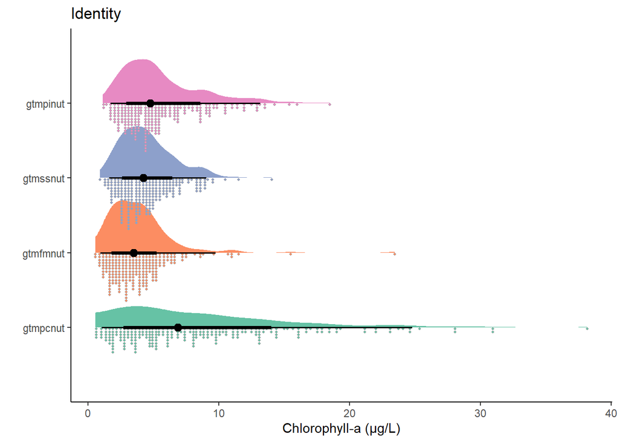

```r
chla_dat %>%
  mutate(station = factor(station,
                          levels = c("gtmpcnut",
                                     "gtmfmnut",
                                     "gtmssnut",
                                     "gtmpinut"))) %>%
  ggplot(aes(x = value, y = station, fill = station)) +
  ggdist::stat_slab(aes(thickness = after_stat(pdf*n)), scale = 0.7) +
  ggdist::stat_dotsinterval(side = "bottom", scale = 0.7, slab_linewidth = NA) +
  scale_fill_brewer(palette = "Set2") +
  theme_classic() +
  theme(legend.position = "none") +
  labs(x = "Chlorophyll-a (\U00B5g/L)",
       y = "",
       title = "Identity")
```

Replotted the data with a log-10 transformation of the data. The data looks much better, although gtmpcnut is still curious.

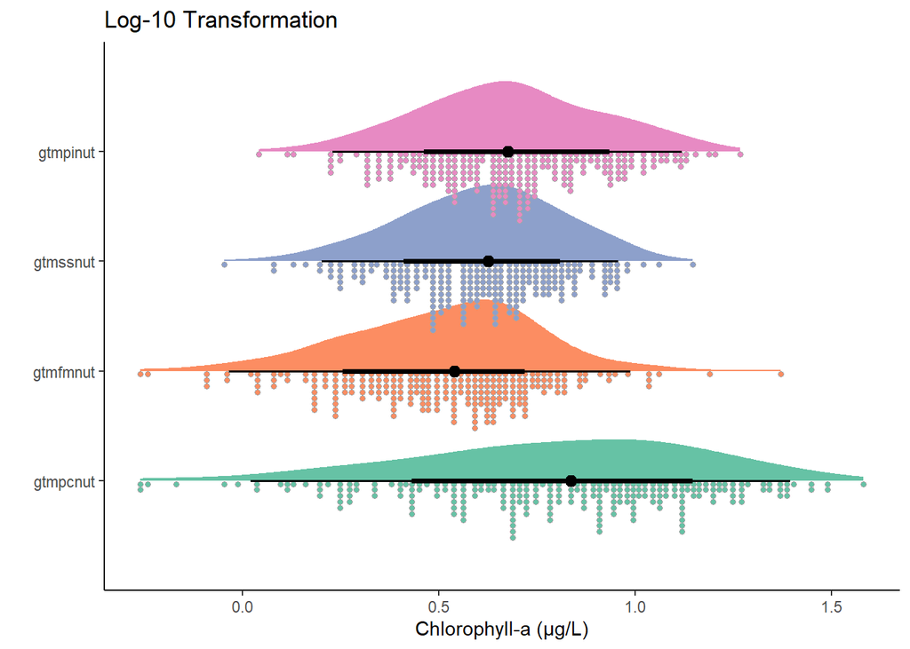

```r
chla_dat %>%
  mutate(station = factor(station,
                          levels = c("gtmpcnut",
                                     "gtmfmnut",
                                     "gtmssnut",
                                     "gtmpinut"))) %>%
  ggplot(aes(x = log10(value), y = station, fill = station)) +
  ggdist::stat_slab(aes(thickness = after_stat(pdf*n)), scale = 0.7) +
  ggdist::stat_dotsinterval(side = "bottom", scale = 0.7, slab_linewidth = NA) +
  scale_fill_brewer(palette = "Set2") +
  theme_classic() +
  theme(legend.position = "none") +
  labs(x = "Chlorophyll-a (\U00B5g/L)",
       y = "",
       title = "Log-10 Transformation")
```

## Q-Q plots

The data should fall along a straight diagonal line.

```r
pi <- chla_dat %>% filter(station == "gtmpinut") %>% mutate(chla_t = log10(value))
ss <- chla_dat %>% filter(station == "gtmssnut") %>% mutate(chla_t = log10(value))
fm <- chla_dat %>% filter(station == "gtmfmnut") %>% mutate(chla_t = log10(value))
pc <- chla_dat %>% filter(station == "gtmpcnut") %>% mutate(chla_t = log10(value))
```

**Pine Island**

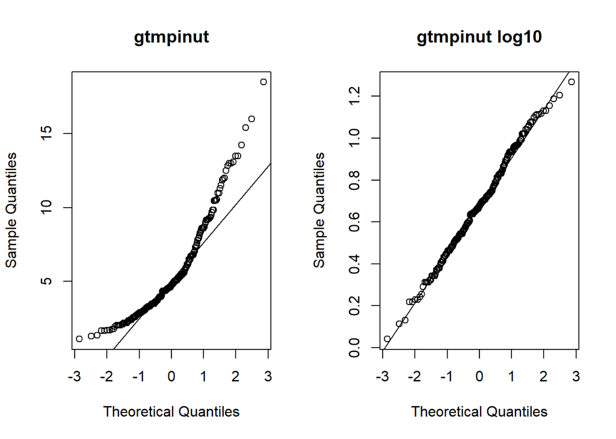

```r
par(mfrow=c(1,2))
qqnorm(pi$value, main ="gtmpinut")
qqline(pi$value)

qqnorm(pi$chla_t, main ="gtmpinut log10")
qqline(pi$chla_t)
```

**San Sebastian**

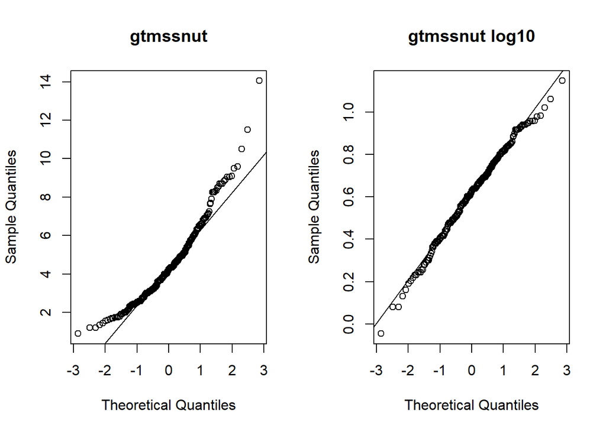

```r
par(mfrow=c(1,2))
qqnorm(ss$value, main ="gtmssnut")
qqline(ss$value)

qqnorm(ss$chla_t, main ="gtmssnut log10")
qqline(ss$chla_t)
```

**Fort Matanzas**

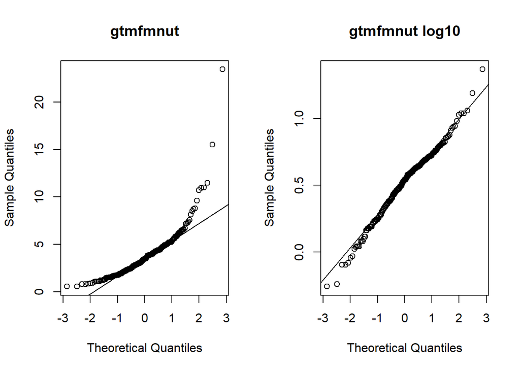

```r
par(mfrow=c(1,2))
qqnorm(fm$value, main ="gtmfmnut")
qqline(fm$value)

qqnorm(fm$chla_t, main ="gtmfmnut log10")
qqline(fm$chla_t)
```

**Pellicer Creek**

gtmpcnut has a non-normal distribution, even after the log-10 transformation.

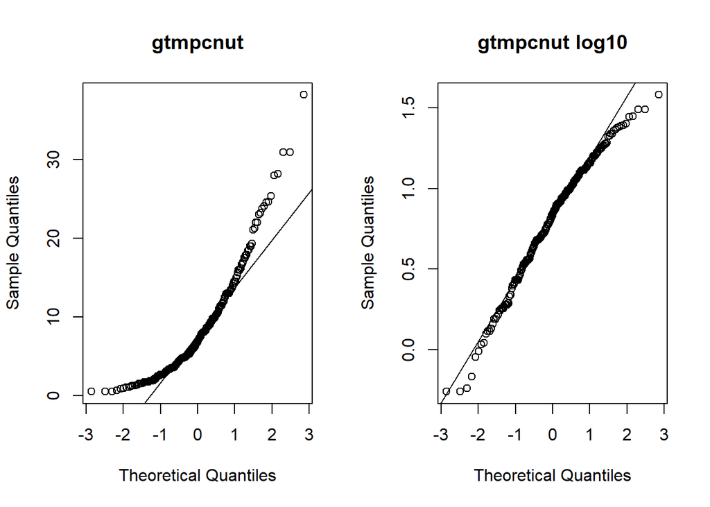

```r
par(mfrow=c(1,2))
qqnorm(pc$value, main ="gtmpcnut")
qqline(pc$value)

qqnorm(pc$chla_t, main ="gtmpcnut log10")
qqline(pc$chla_t)
```

## Normality Testing

Shapiro-Wilk Normality Tests on log-10 transformed data

```r
shapiro.test(pi$chla_t)
```

```
    Shapiro-Wilk normality test

data:  pi$chla_t
W = 0.99507, p-value = 0.6496
```

```r
shapiro.test(ss$chla_t)
```

```
    Shapiro-Wilk normality test

data:  ss$chla_t
W = 0.99376, p-value = 0.4398
```

```r
shapiro.test(fm$chla_t)
```

```
    Shapiro-Wilk normality test

data:  fm$chla_t
W = 0.98842, p-value = 0.05426
```

```r
shapiro.test(pc$chla_t)
```

```
    Shapiro-Wilk normality test

data:  pc$chla_t
W = 0.98131, p-value = 0.003701
```

```r
ks.test(pc$chla_t, 'pnorm')
```

```
    Asymptotic one-sample Kolmogorov-Smirnov test

data:  pc$chla_t
D = 0.52274, p-value < 2.2e-16
alternative hypothesis: two-sided
```

```r
rm(pi, ss, fm, pc)
```

Pellicer Creek (“gtmpcnut”) fails normality tests (Shapiro-Wilk and Kolmogorov-Smirnov Tests) even after log10 transformations.

## Trends

From the vignette for `wqtrends`, the generalized additive model (GAM) fits additive smoothing functions to describe variations in the response variable `value` over time, which is measured as a continuous number in `cont_year`. The GAM used in this model is

chl ~ s(cont_year, k = *large*)

and therefore `anlz_gam()` is used to fit the model. The upper limit of `k` (number of knots) *“should be large enough to allow sufficient flexibility in the smoothing term”* and is recommended as 12 times the number of years for the input data, however the number of knots can decrease until the data can be modeled (if insufficent data are available).

**Pine Island**

```r
tomod <- chla_dat %>%
          filter(station %in% "gtmpinut") # only keep pine island data

mod <- wqtrends::anlz_gam(tomod, trans = "log10")
```

```
reducing knots for cont_year spline from 240
```

```r
mod
```

```
Family: gaussian
Link function: identity

Formula:
value ~ s(cont_year, k = 220)

Estimated degrees of freedom:
83.3  total = 84.33

GCV score: 0.03131698
```

“GCV” is the generalized cross-validation score, which minimizes out-of-sample prediction error. It penalizes the net curve of a spline.

Now to assess fit of the model by using `anlz_smooth()` to assess individual smoother functions and `anlz_fit()` for overall fit.

```r
anlz_smooth(mod)
```

```
      smoother      edf   Ref.df        F p.value
1 s(cont_year) 83.32591 103.2462 4.137228       0
```

```r
anlz_fit(mod)
```

```
             AIC        GCV        R2
GCV.Cp -185.2911 0.03131698 0.6308997
```

Using the basic smoother with just `cont_year` as a variable, the test statistics are okay. The AIC is low and there is a decent R2 value.

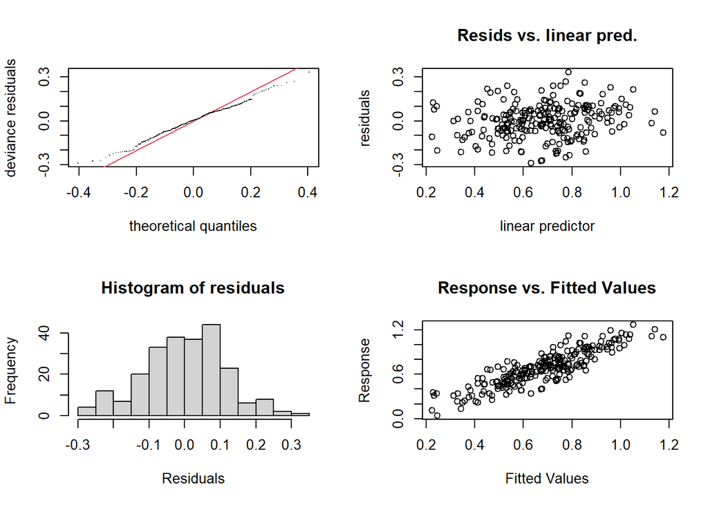

```
Method: GCV   Optimizer: magic
Smoothing parameter selection converged after 7 iterations.
The RMS GCV score gradient at convergence was 2.913665e-06 .
The Hessian was positive definite.
Model rank =  220 / 220

Basis dimension (k) checking results. Low p-value (k-index<1) may
indicate that k is too low, especially if edf is close to k'.

                k'   edf k-index p-value
s(cont_year) 219.0  83.3    1.35       1
```

```r
par(mfrow=c(2,2))
gam.check(mod)
```

Estimate results by day of year

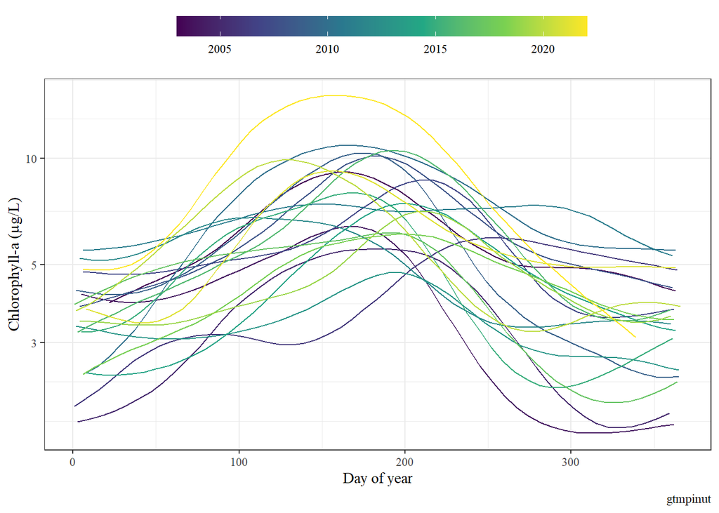

```r
ylab <- "Chlorophyll-a (\U00B5g/L)"
show_prddoy(mod, ylab = ylab) + labs(caption = "gtmpinut")
```

Predictions for the model across the entire time series. Points are the observed data and the lines are the predicted. I have modified the `show_prdseries()` function from the `wqtrends` package to `show_prdseries_mod()` for basic aesthetic changes.

```r
show_prdseries_mod <-  function (mod, ylab, alpha = 0.7, base_size = 11, xlim = NULL,
    ylim = NULL, site)
{
    prds <- anlz_prd(mod)
    trans <- unique(prds$trans)
    tobacktrans <- mod$model %>% dplyr::mutate(trans = mod$trans)
    moddat <- anlz_backtrans(tobacktrans) %>% dplyr::mutate(date = lubridate::date_decimal(cont_year),
        date = as.Date(date))
    p <- ggplot2::ggplot(prds, ggplot2::aes(x = date)) +
          ggplot2::geom_point(data = moddat,
                    ggplot2::aes(y = value), color = "gray75", size = 1) +
      ggplot2::geom_line(ggplot2::aes(y = value),
        linewidth = 0.75, alpha = alpha, colour = "#56B4E9") +
      ggplot2::theme_bw(base_family = "serif",
        base_size = base_size) +
      ggplot2::theme(legend.position = "top",
        legend.title = ggplot2::element_blank(),
        axis.title.x = ggplot2::element_blank(),
        axis.text = element_text(size = 12, color = "black")) +
      ggplot2::labs(y = ylab,
                    title = site) +
      ggplot2::coord_cartesian(xlim = xlim, ylim = ylim)
    if (trans != "ident")
        p <- p + ggplot2::scale_y_log10()
    return(p)
}
```

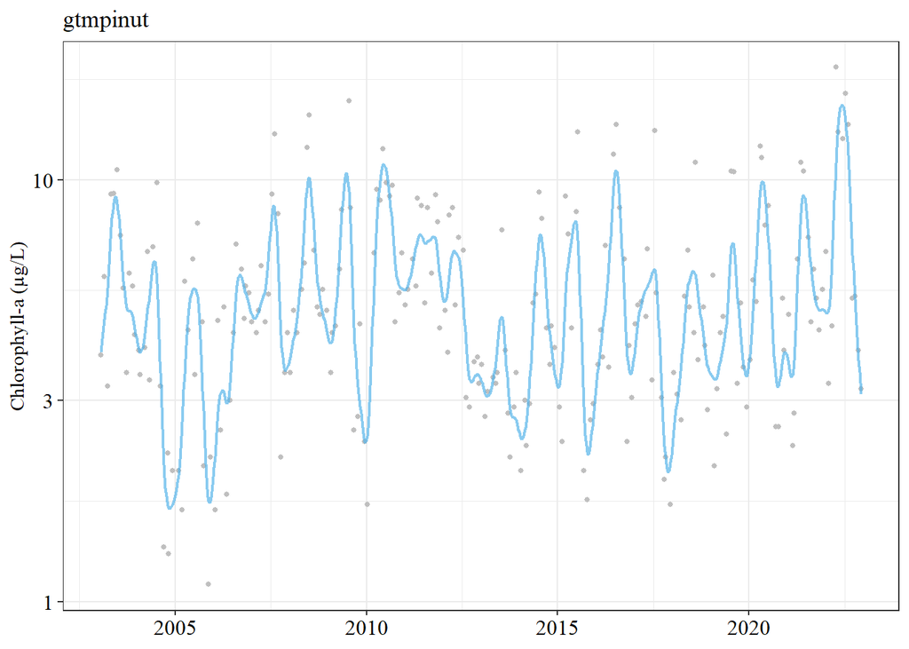

```r
show_prdseries_mod(mod, ylab = "Chlorophyll-a (\U00B5g/L)", site = "gtmpinut")
```

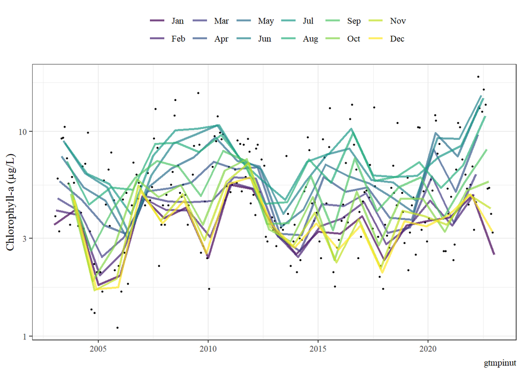

```r
show_prdseason(mod, ylab = ylab) + labs(caption = "gtmpinut")
```

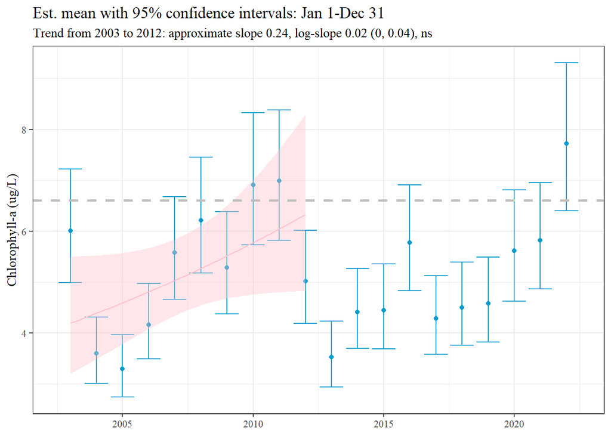

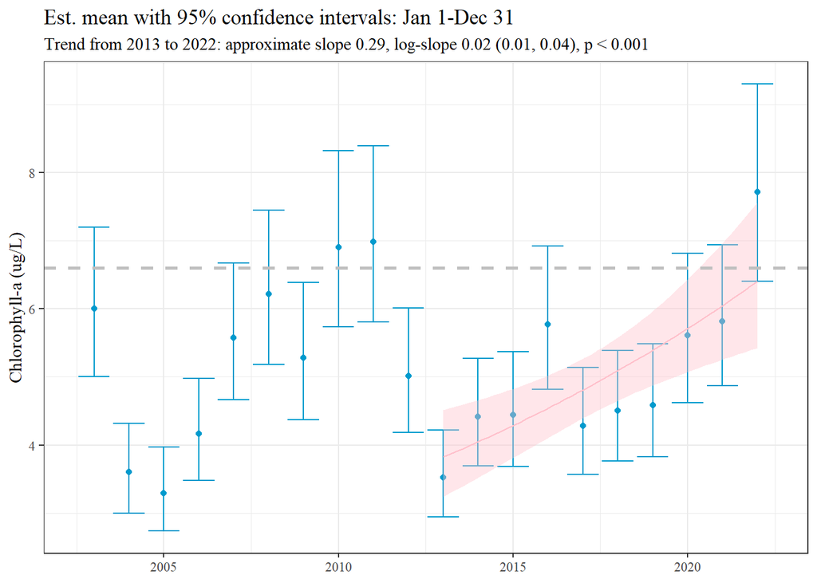

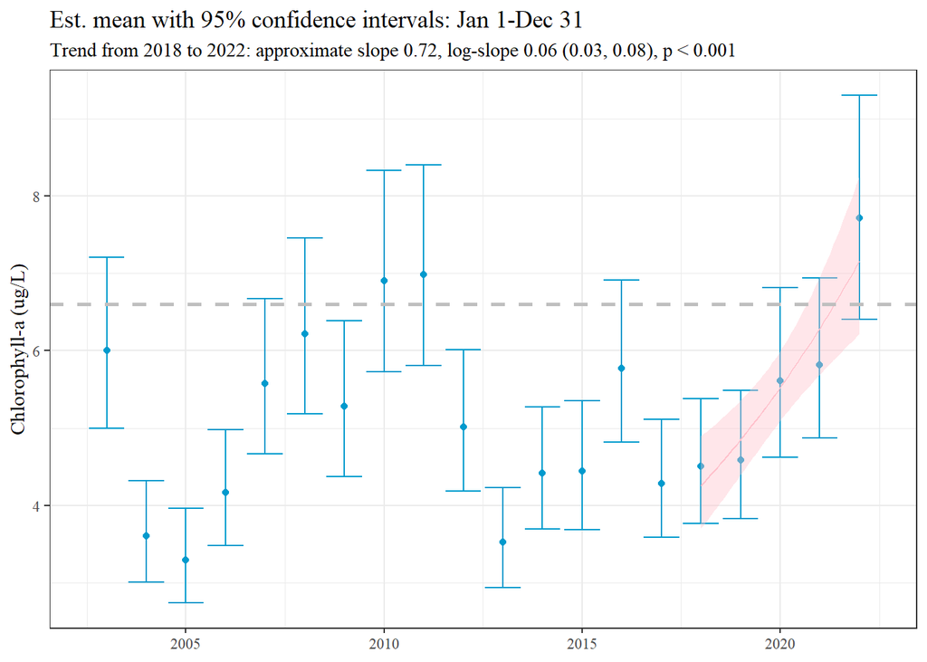

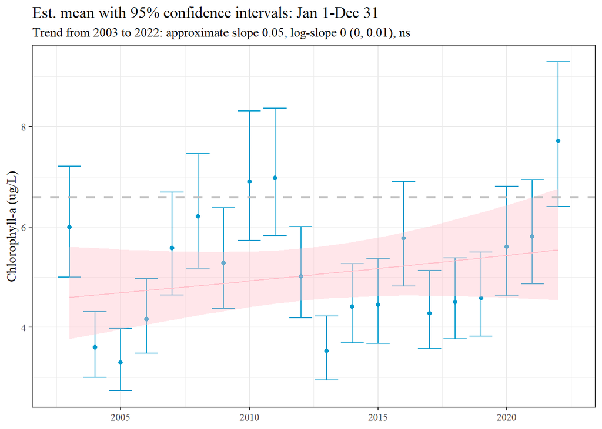

```r
trndseason <- anlz_trndseason(mod, doystr = 1, doyend = 365, justify = "center", win = 5)
head(trndseason)
```

```
# A tibble: 6 × 12
     yr   met     se bt_lwr bt_upr bt_met dispersion      yrcoef        pval
  <dbl> <dbl>  <dbl>  <dbl>  <dbl>  <dbl>      <dbl>       <dbl>       <dbl>
1  2003 0.755 0.0411   4.99   7.23   6.00     0.0201 NaN         NaN
2  2004 0.533 0.0401   3.01   4.32   3.60     0.0201 NaN         NaN
3  2005 0.495 0.0404   2.75   3.96   3.30     0.0201   0.0000198   1.00
4  2006 0.596 0.0399   3.48   4.98   4.16     0.0201   0.0701      0.0000105
5  2007 0.723 0.0402   4.65   6.69   5.58     0.0201   0.0588      0.00817
6  2008 0.770 0.0405   5.18   7.46   6.21     0.0201   0.0419      0.0221
# ℹ 3 more variables: appr_yrcoef <dbl>, yrcoef_lwr <dbl>, yrcoef_upr <dbl>
```

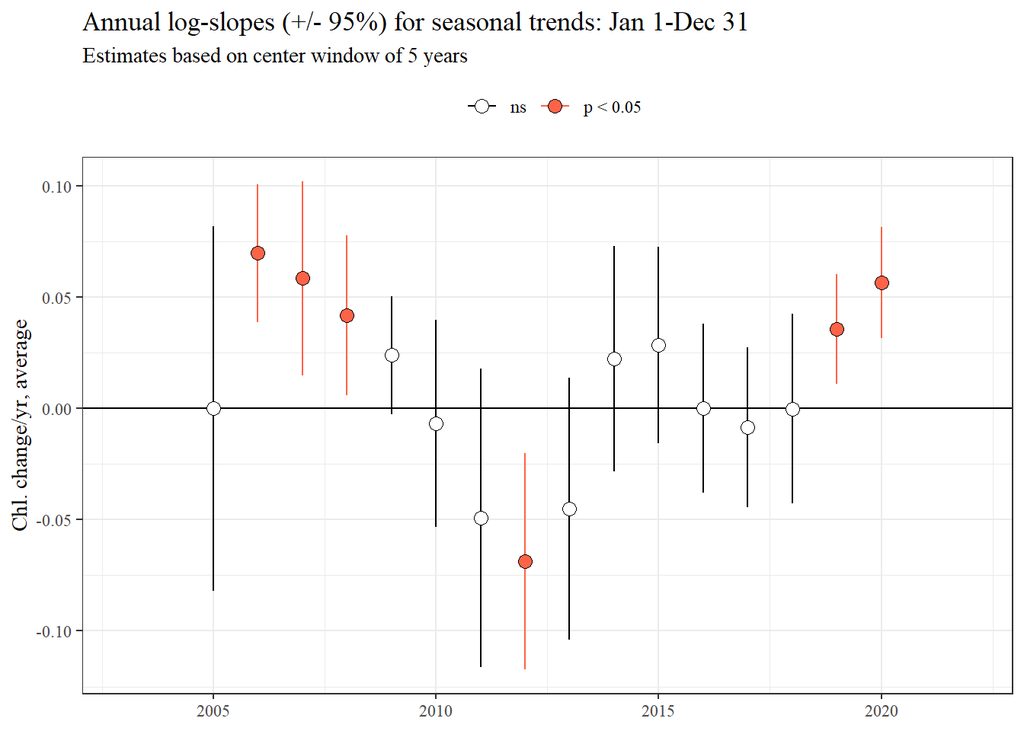

```r
show_trndseason(mod, doystr = 1, doyend = 365, justify = "center", win = 5, ylab = "Chl. change/yr, average")
```

**San Sebastian**

```r
tomod <- chla_dat %>%
          filter(station %in% "gtmssnut") # only keep pine island data

mod <- wqtrends::anlz_gam(tomod, trans = "log10")
```

```
reducing knots for cont_year spline from 240
```

```r
mod
```

```
Family: gaussian
Link function: identity

Formula:
value ~ s(cont_year, k = 220)

Estimated degrees of freedom:
76.3  total = 77.29

GCV score: 0.02431479
```

Now to assess fit of the model by using `anlz_smooth()` to assess individual smoother functions and `anlz_fit()` for overall fit.

```r
anlz_smooth(mod)
```

```
      smoother      edf   Ref.df        F p.value
1 s(cont_year) 76.29136 94.69491 4.245355       0
```

from the help: *“the estimated degrees of freedom (`edf`), the reference degrees of freedom (`Ref.df`), the test statistic (`F`), and significance of the component (`p-value`). The significance of the component is in part based on the difference between `edf` and `Ref.df`.”*

```r
anlz_fit(mod)
```

```
             AIC        GCV        R2
GCV.Cp -236.6915 0.02431479 0.6172907
```

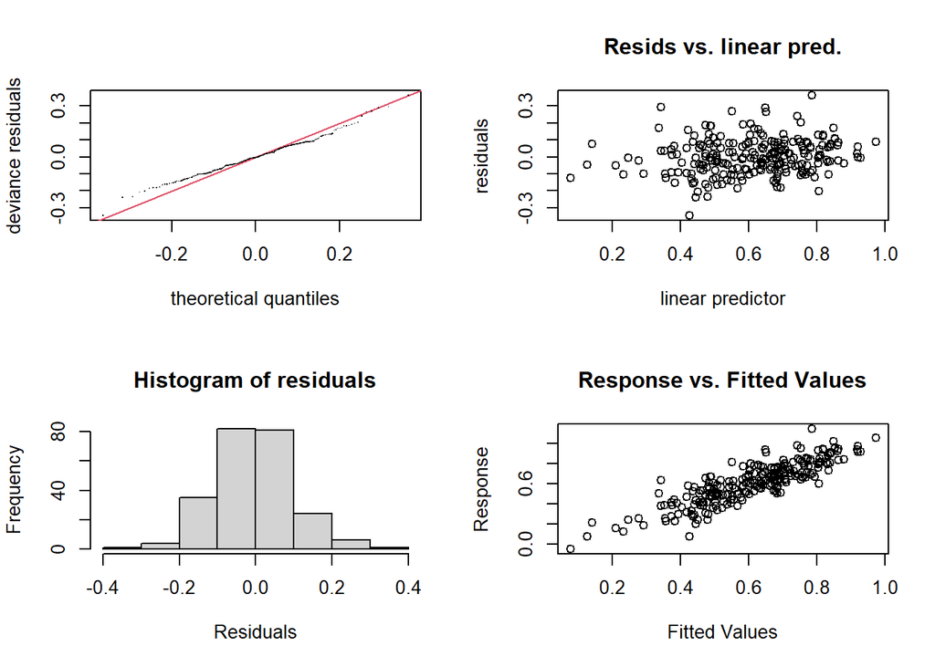

```
Method: GCV   Optimizer: magic
Smoothing parameter selection converged after 4 iterations.
The RMS GCV score gradient at convergence was 5.285926e-06 .
The Hessian was positive definite.
Model rank =  220 / 220

Basis dimension (k) checking results. Low p-value (k-index<1) may
indicate that k is too low, especially if edf is close to k'.

                k'   edf k-index p-value
s(cont_year) 219.0  76.3    1.39       1
```

```r
par(mfrow=c(2,2))
gam.check(mod)
```

Estimate results by day of year

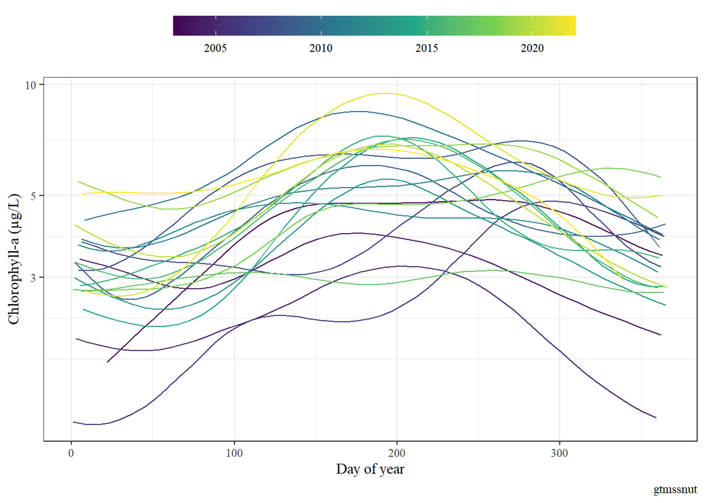

```r
ylab <- "Chlorophyll-a (\U00B5g/L)"
show_prddoy(mod, ylab = ylab) + labs(caption = "gtmssnut")
```

Predictions for the model across the entire time series. Points are the observed data and the lines are the predicted.

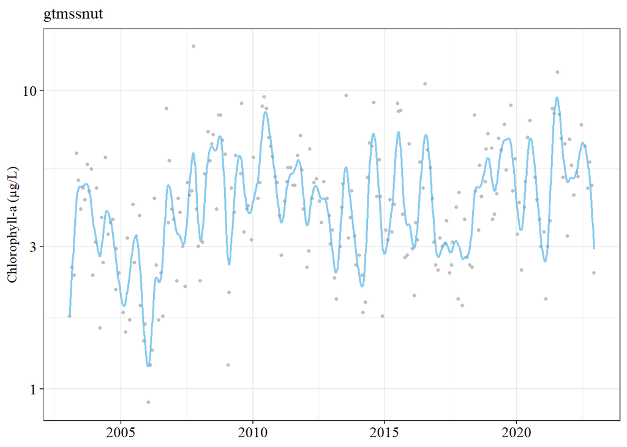

```r
show_prdseries_mod(mod, ylab = "Chlorophyll-a (\U00B5g/L)", site = "gtmssnut")
```

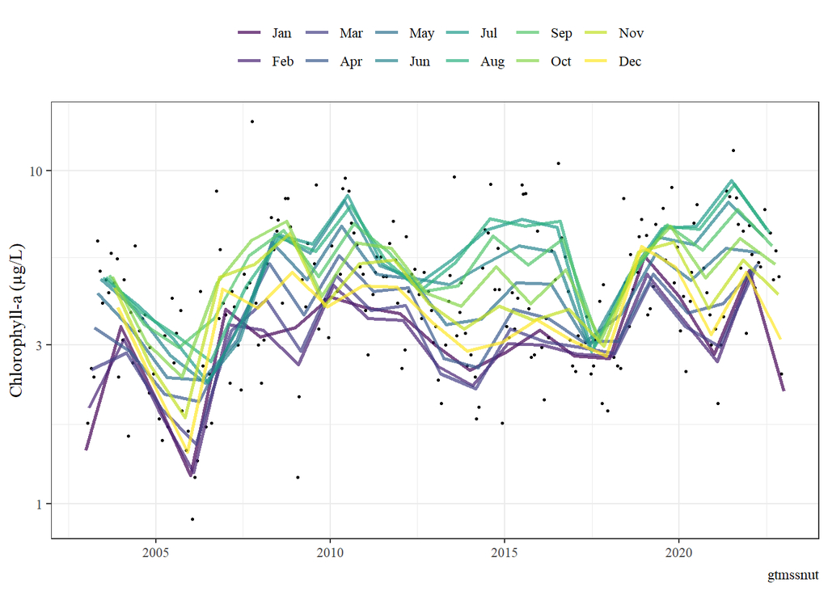

```r
show_prdseason(mod, ylab = ylab) + labs(caption = "gtmssnut")
```

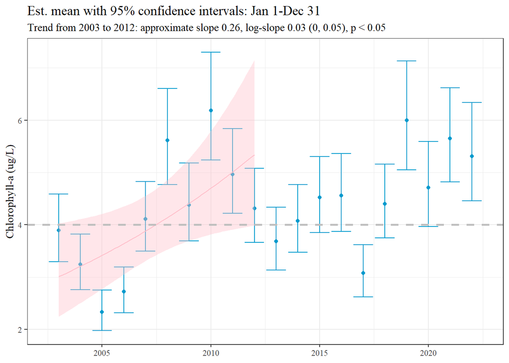

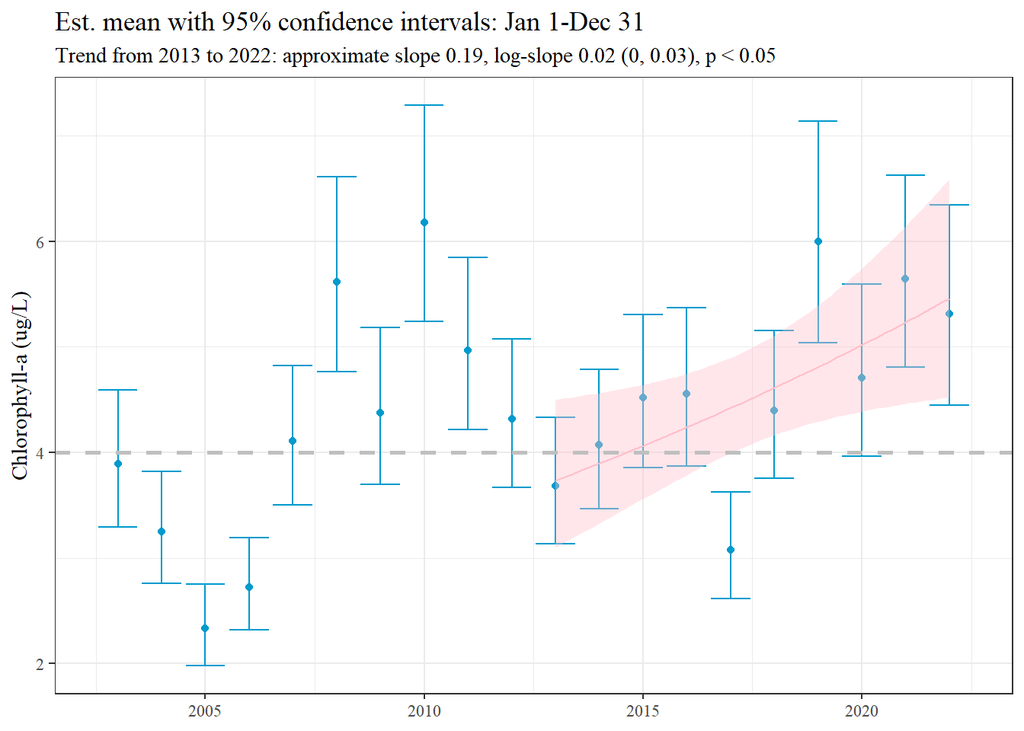

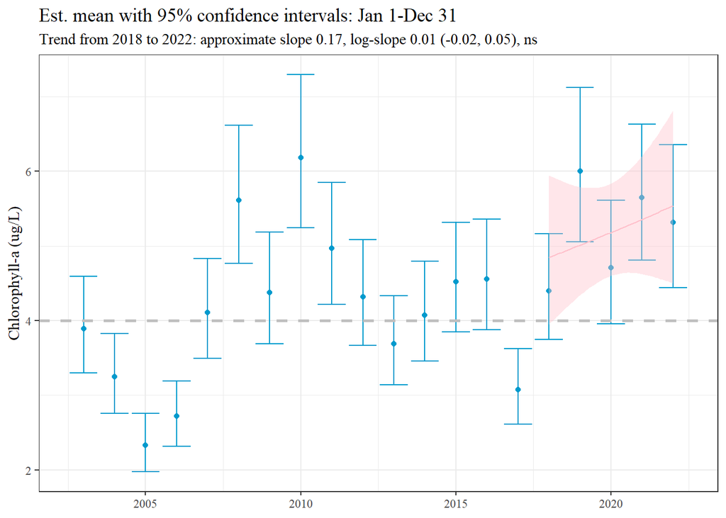

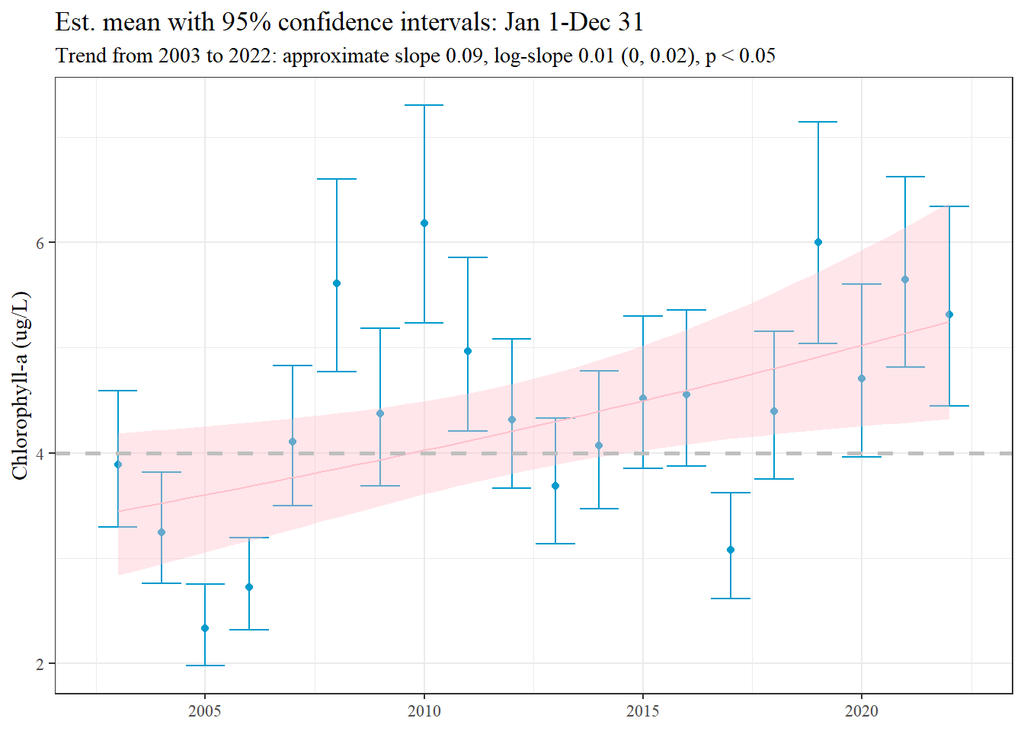

**Fort Matanzas**

```r
tomod <- chla_dat %>%
          filter(station %in% "gtmfmnut") # only keep pine island data

mod <- wqtrends::anlz_gam(tomod, trans = "log10")
```

```
reducing knots for cont_year spline from 240
```

```r
mod
```

```
Family: gaussian
Link function: identity

Formula:
value ~ s(cont_year, k = 220)

Estimated degrees of freedom:
103  total = 103.87

GCV score: 0.02737843
```

Now to assess fit of the model by using `anlz_smooth()` to assess individual smoother functions and `anlz_fit()` for overall fit.

```r
anlz_smooth(mod)
```

```
      smoother      edf   Ref.df        F p.value
1 s(cont_year) 102.8703 126.6905 6.187952       0
```

from the help: *“the estimated degrees of freedom (`edf`), the reference degrees of freedom (`Ref.df`), the test statistic (`F`), and significance of the component (`p-value`). The significance of the component is in part based on the difference between `edf` and `Ref.df`.”*

```r
anlz_fit(mod)
```

```
             AIC        GCV       R2
GCV.Cp -243.4309 0.02737843 0.761577
```

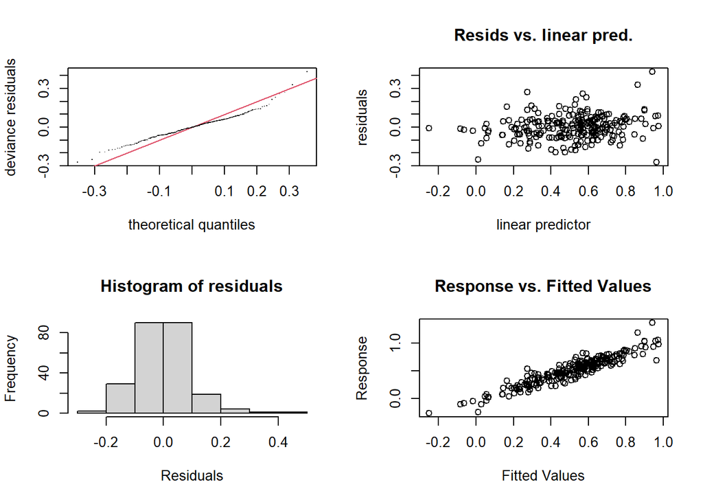

```
Method: GCV   Optimizer: magic
Smoothing parameter selection converged after 7 iterations.
The RMS GCV score gradient at convergence was 1.667784e-06 .
The Hessian was positive definite.
Model rank =  220 / 220

Basis dimension (k) checking results. Low p-value (k-index<1) may
indicate that k is too low, especially if edf is close to k'.

              k' edf k-index p-value
s(cont_year) 219 103    1.44       1
```

```r
par(mfrow=c(2,2))
gam.check(mod)
```

Estimate results by day of year

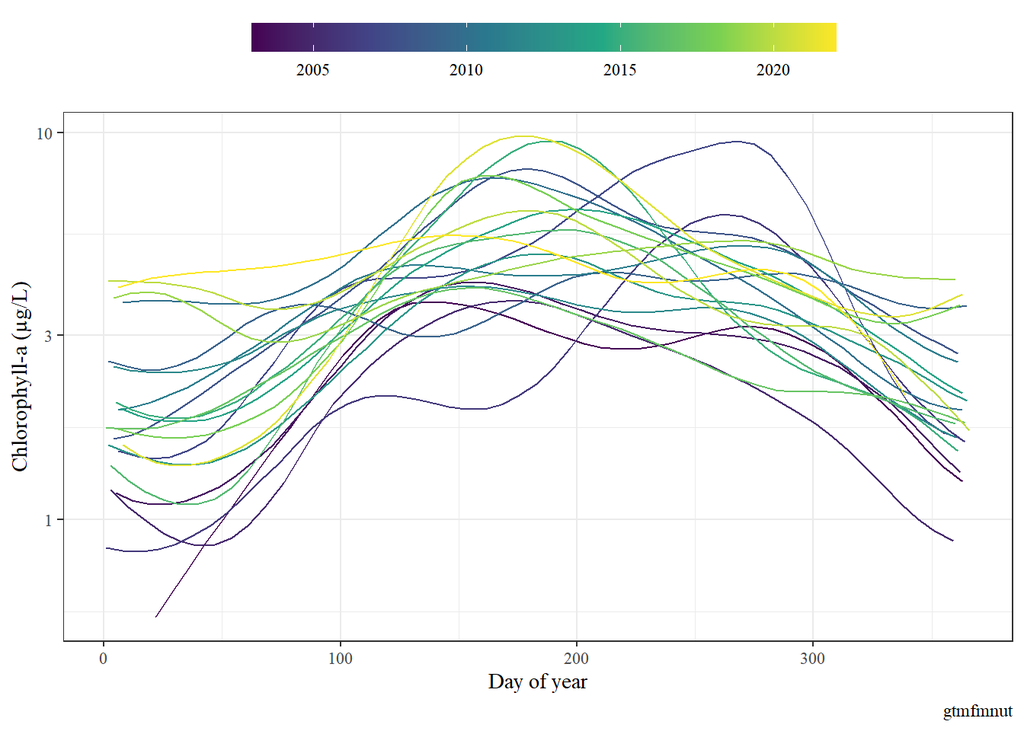

```r
ylab <- "Chlorophyll-a (\U00B5g/L)"
show_prddoy(mod, ylab = ylab) + labs(caption = "gtmfmnut")
```

Predictions for the model across the entire time series. Points are the observed data and the lines are the predicted.

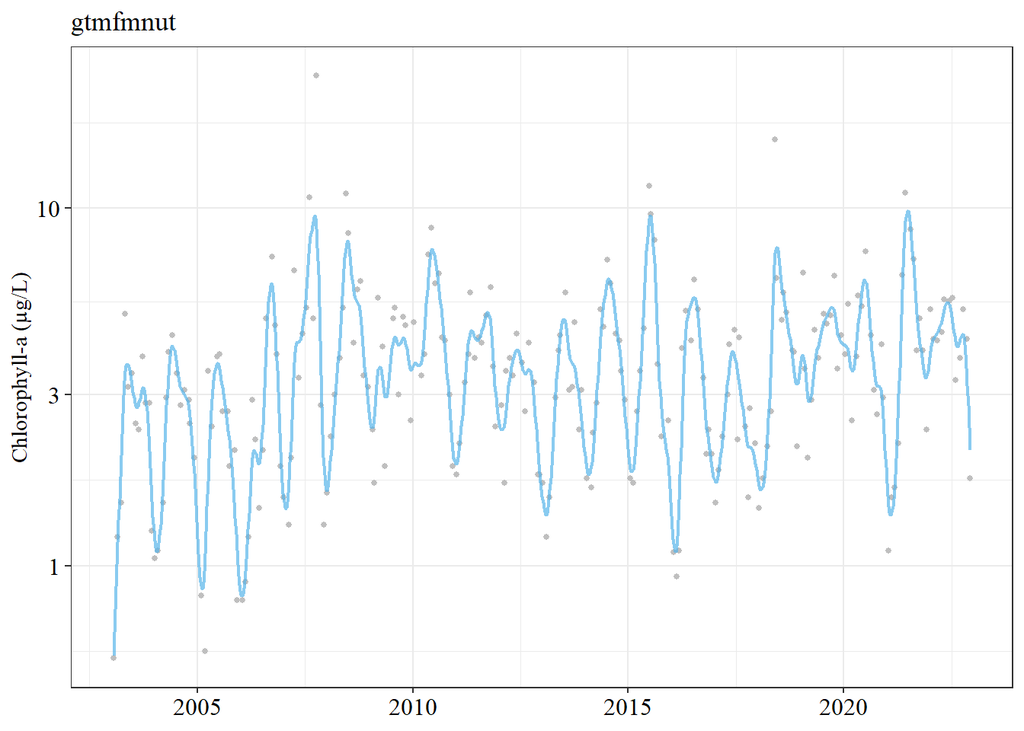

```r
show_prdseries_mod(mod, ylab = "Chlorophyll-a (\U00B5g/L)", site = "gtmfmnut")
```

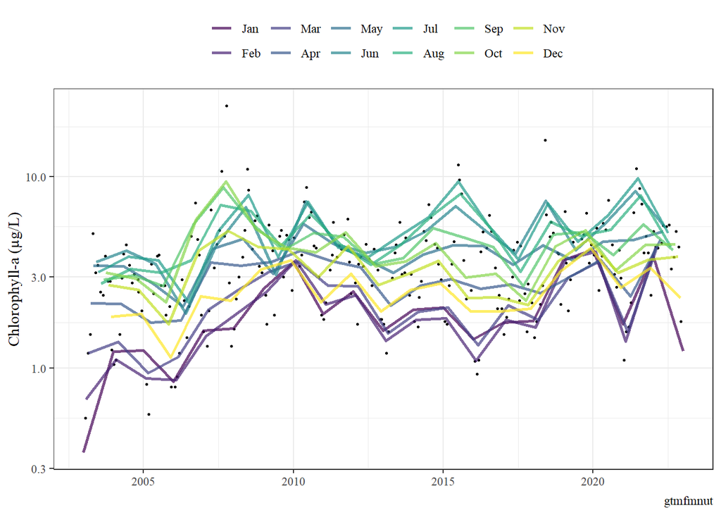

```r
show_prdseason(mod, ylab = ylab) + labs(caption = "gtmfmnut")
```

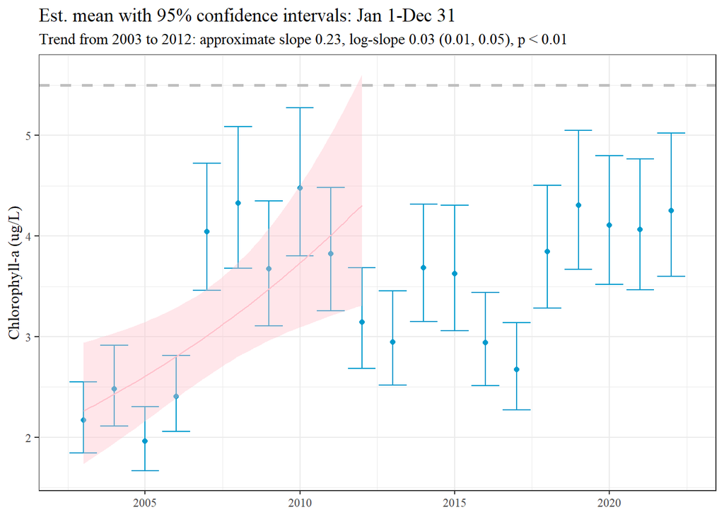

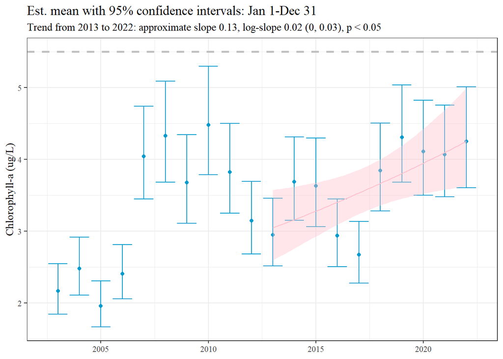

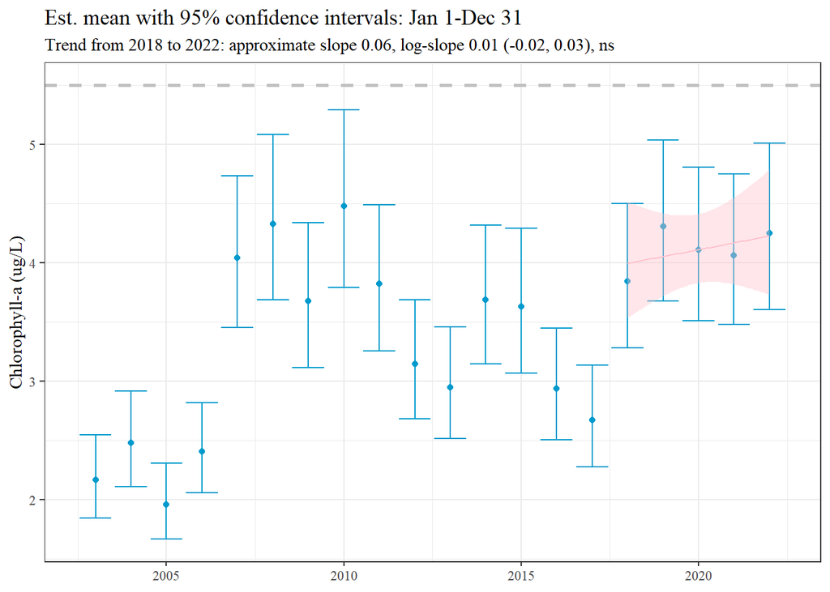

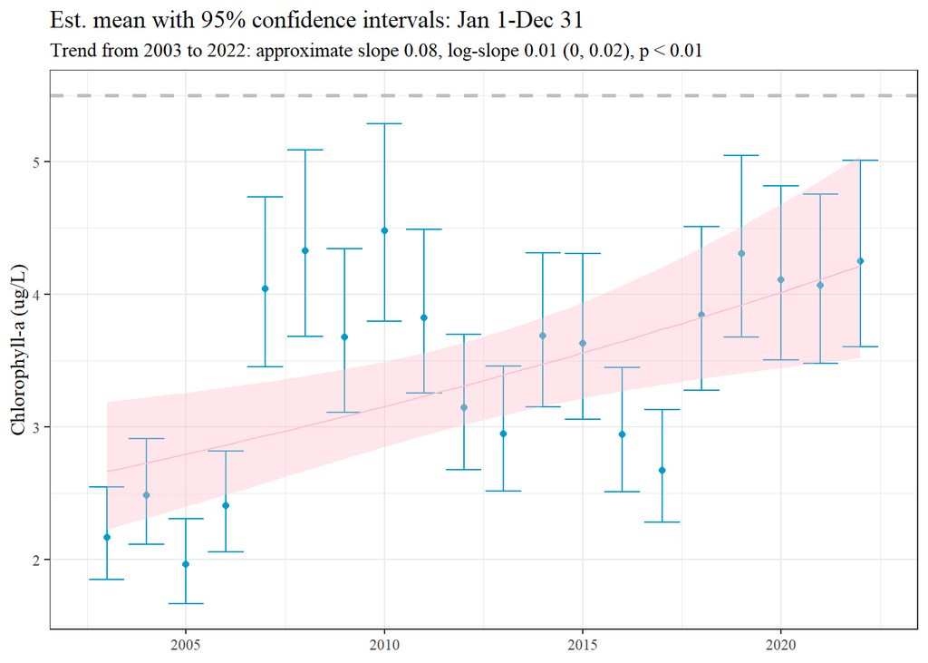

**Pellicer Creek**

*did not meet normality assumptions*

```r
tomod <- chla_dat %>%
          filter(station %in% "gtmpcnut") # only keep pine island data

mod <- wqtrends::anlz_gam(tomod, trans = "log10")
```

```
reducing knots for cont_year spline from 240
```